# EDA

Ignacio Vellido

11/13/2020

# Intro

Para este trabajo contamos con dos datasets distintos: **autoMPG6** para aplicar Regresión y **haberman** para aplicar Clasificación.

## Descripciones de los problemas

### autoMPG6

http://lib.stat.cmu.edu/datasets/cars.desc

Este dataset codifica el consumo de gasolina de distintos coches (en millas por galón, Mpg) en base a las siguientes características:

1. Displacement: Indica la cilindrada del coche, la suma del volumen útil de los cilindros del motor, medido en pulgadas cúbicas.
2. Horse_power: Mide la potencia del coche.
3. Weight: Peso en libras.
4. Acceleration: Aceleración del coche de 0 a 60 millas por hora, medido en segundos.
5. Model_year: Indica las dos últimas cifras del año de producción.

El objetivo es poder predecir, en base a los cinco atributos, el consumo Mpg de un nuevo coche:

6. Mpg: Millas-por-galón, indica la cantidad de galones (1G ≈ 3,78L) de fuél que consume un vehículo al recorrer una milla (1m ≈ 1,6km).

# Análisis Estadístico de Datos

### autoMPG6

La descripción del problema nos da alguna información adicional sobre las variables:

1. Displacement: Variable numérica continua, contamos con valores reales en el rango [68.0,455.0].
2. Horse_power: Variable numérica continua, contamos con valores enteros en el rango [46,230].
3. Weight: Variable numérica continua, contamos con valores enteros en el rango [1613,5140].
4. Acceleration: Variable numérica continua, contamos con valores reales en el rango [8.0,24.8].
5. Model_year: Variable numérica discreta, contamos con valores enteros en el rango [70,82].
6. Mpg: Variable numérica continua, contamos con valores reales en el rango [9.0,46.6].

#### Hipótesis de partida

- H.1: Horse_power puede influir en Mpg: A más potencia, más consumo.
- H.2: Weight debe influir en Mpg: Un coche más pesado debería consumir más.
- H.3: Debería haber correlación entre displacement (cilindrada) con horse y acceleration
- H.4: Horse y acceleration podrían estar relacionadas
- H.5: Viendo que contamos con un rango pequeño de años, no debería haber un cambio significativo de prestaciones entre años
- H.6: Pero debería existir una tendencia de mejora de prestaciones con los años, incluyendo aumento de Displacement, Horse_power y Acceleration.
- H.7: Model_year podría no mostrar relación con Mpg: Pese al paso de los años si contamos con diferentes tipos de vehículos (todoterrenos, familiares, deportivos…) podría haber un consumo dispar. (Si existiera tendencia, viendo que los años son de las últimas décadas del siglo XX, podría ir el consumo hacia abajo)
- H.8: Esta última hipótesis se puede aplicar al resto de variables, indicándonos que Model_year no debería tener relevancia para este problema de regresión.
- H.9: Horse_power podría depender de las variables Displacement y Weight

Cargamos los datos:

```r
names <- c("Displacement", "Horse_power", "Weight", "Acceleration", "Model_year", "Mpg")

auto <- read_csv("Data/autoMPG6/autoMPG6.dat", comment = "@", col_names = names)
```

Antes de comenzar a analizar las variables nos plantemos una cuestión: ¿Debemos considerar Model_year como una variable numérica o como un factor categórico? Aunque por la hipótesis H.7 podríamos acabar no eligiendo la variable para el problema, es necesario plantearse esta cuestión antes de comenzar.

En un principio, el dataset está planteado para regresión, por lo que tendríamos dos opciones: - Mantenerlo como categórico y generar variables dummy (Valores 0-1 para indicar si la instancia es de ese año). Suponiendo que tenemos al menos una instancia de cada año, esto nos generaría 12 variables nuevas. - Mantenerlo como numérico, pero teniendo cuidado de cómo interpretar el año.

Proseguimos con tanto dejando Model_year como variable numérica.

#### Análisis univariable

```r
head(auto)
```

| Displacement | Horse_power | Weight | Acceleration | Model_year | Mpg |
| --- | --- | --- | --- | --- | --- |
| 91 | 70 | 1955 | 20.5 | 71 | 26.0 |
| 232 | 100 | 2789 | 15.0 | 73 | 18.0 |
| 350 | 145 | 4055 | 12.0 | 76 | 13.0 |
| 318 | 140 | 4080 | 13.7 | 78 | 17.5 |
| 113 | 95 | 2372 | 15.0 | 70 | 24.0 |
| 97 | 60 | 1834 | 19.0 | 71 | 27.0 |

Hacemos summary para sacar datos de relevancia

```r
summary(auto)
```

```
  Displacement    Horse_power        Weight      Acceleration     Model_year
 Min.   : 68.0   Min.   : 46.0   Min.   :1613   Min.   : 8.00   Min.   :70.00
 1st Qu.:105.0   1st Qu.: 75.0   1st Qu.:2225   1st Qu.:13.78   1st Qu.:73.00
 Median :151.0   Median : 93.5   Median :2804   Median :15.50   Median :76.00
 Mean   :194.4   Mean   :104.5   Mean   :2978   Mean   :15.54   Mean   :75.98
 3rd Qu.:275.8   3rd Qu.:126.0   3rd Qu.:3615   3rd Qu.:17.02   3rd Qu.:79.00
 Max.   :455.0   Max.   :230.0   Max.   :5140   Max.   :24.80   Max.   :82.00
      Mpg
 Min.   : 9.00
 1st Qu.:17.00
 Median :22.75
 Mean   :23.45
 3rd Qu.:29.00
 Max.   :46.60
```

El dataset no cuenta con valores repetidos

```r
sum(duplicated(auto))
```

```
[1] 0
```

Ni missing values

```r
sum(is.na(auto))
```

```
[1] 0
```

Vamos a sacar plots de cada variable para verlo mejor

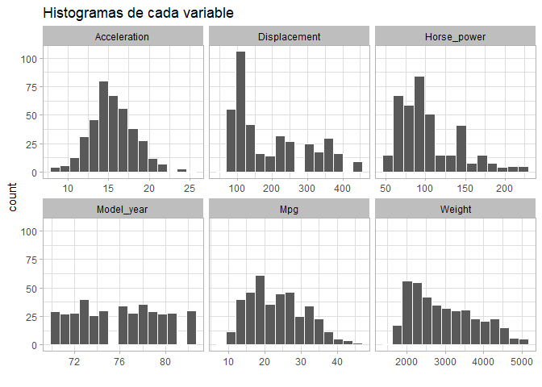

```r
ggplot(gather(auto), aes(value)) +
  geom_histogram(bins = 15, color="white") +
  facet_wrap(~key, scales = 'free_x') +
  theme_light() +
  theme(strip.background = element_rect(fill="grey", size=2))+
  theme(strip.text = element_text(colour = 'black')) +
  labs(title="Histogramas de cada variable", x = "")
```

Una a una

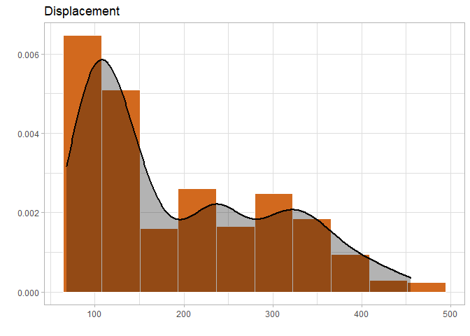

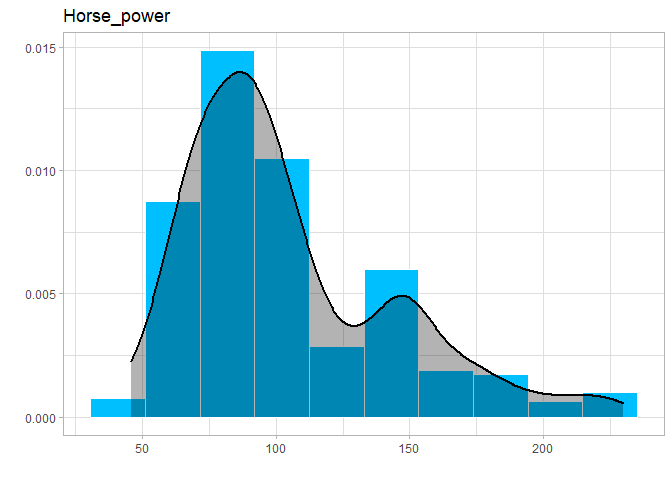

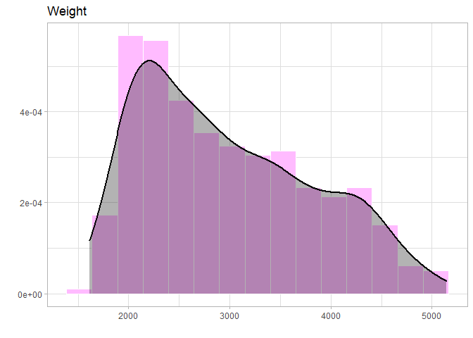

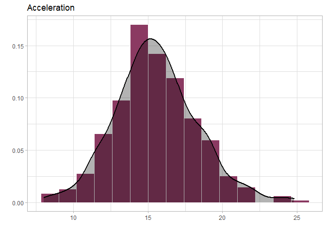

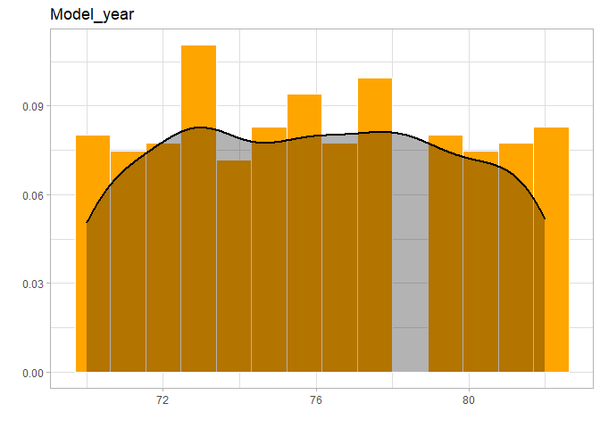

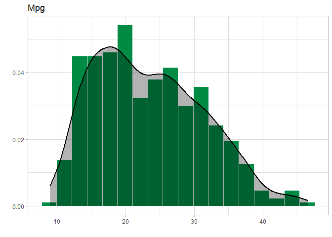

```r
colors <- c("chocolate", "deepskyblue1", "plum1", "hotpink4", "orange", "springgreen4")
bins <- c(10,10,15,15,14,18)
plt <- list(length = length(names))

for (i in 1:length(names)) {
  ggplot(auto, aes_string(x=names[i])) +
    geom_histogram(aes(y=..density..), bins=bins[i], color="white", fill=colors[i]) +
    geom_density(alpha=.3, fill="black", size=1) +
    labs(title="", x="", y="") +
    theme_light() -> plt[[i]]

  print(plt[[i]] + labs(title=sprintf("%s", names[i]), x=""))
}
```

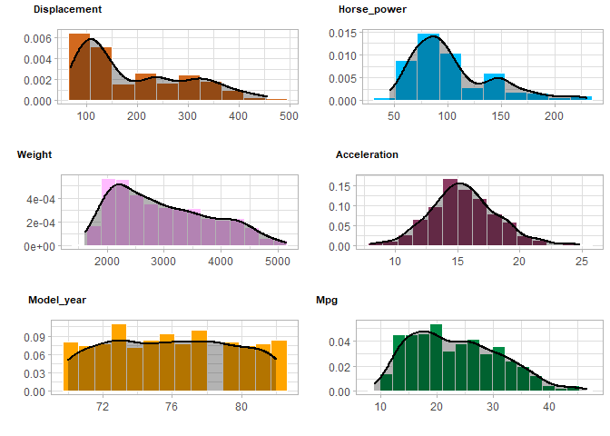

```r
plot_grid(plotlist=plt, ncol=2, labels = names, label_size = 8)
```

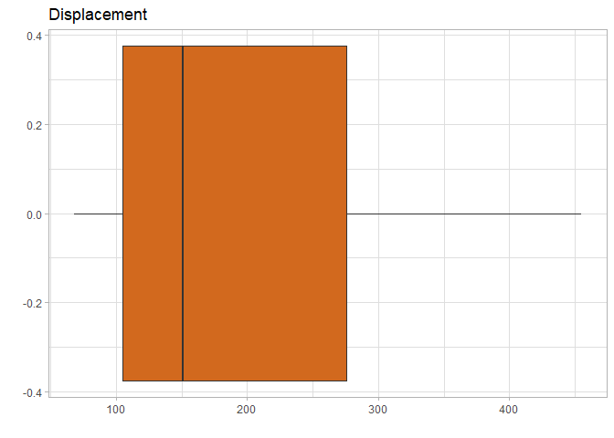

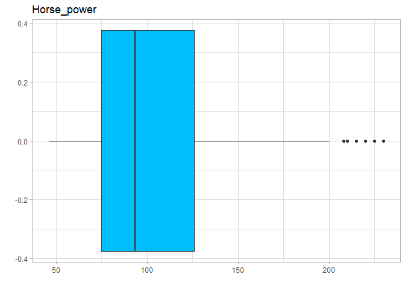

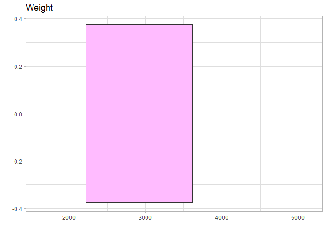

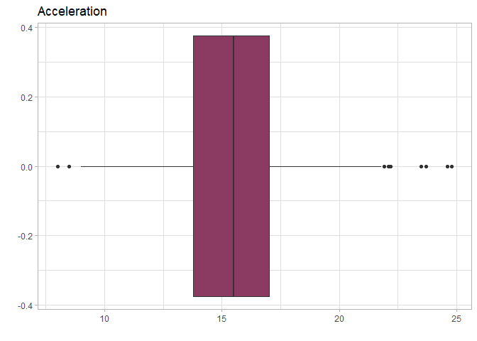

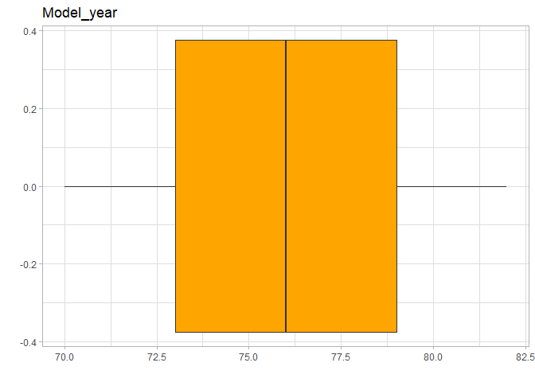

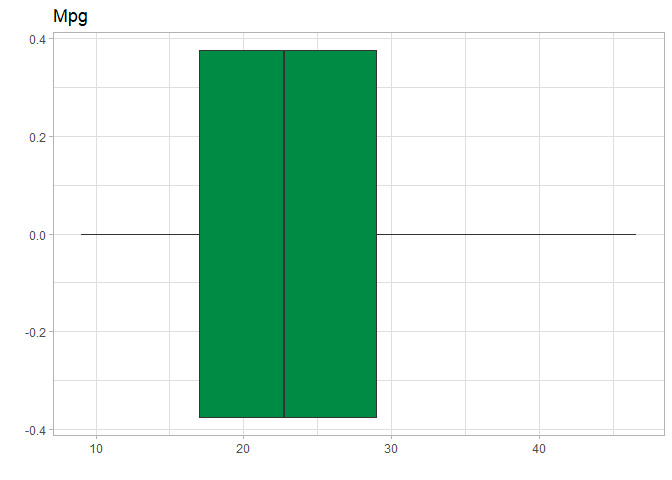

```r
colors <- c("chocolate", "deepskyblue1", "plum1", "hotpink4", "orange", "springgreen4")
bins <- c(10,10,15,15,14,18)
plt <- list(length = length(names))

for (i in 1:length(names)) {
  ggplot(auto, aes_string(x=names[i])) +
    geom_boxplot(fill = colors[i]) +
    labs(title="", x="", y="") +
    theme_light() -> plt[[i]]

  print(plt[[i]] + labs(title=sprintf("%s", names[i]), x=""))
}
```

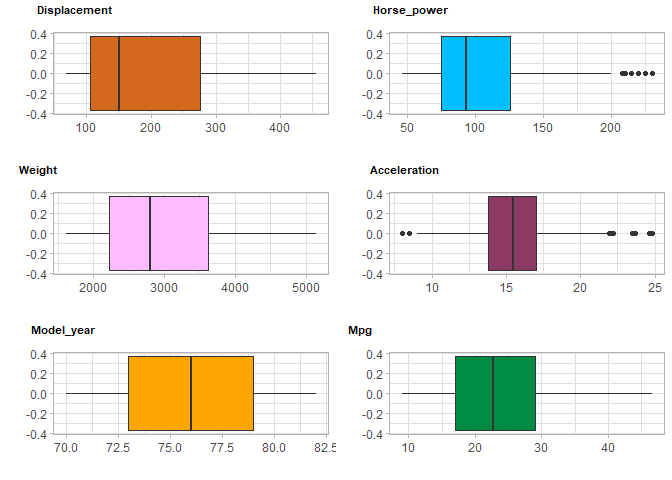

```r
plot_grid(plotlist=plt, ncol=2, labels = names, label_size = 8)
```

Podemos comparar los rangos intercuartiles si estandarizamos antes el dataset

```r
scale(auto) %>% apply(2, IQR)
```

```
Displacement  Horse_power       Weight Acceleration   Model_year          Mpg
    1.631723     1.324980     1.635856     1.178021     1.628781     1.537475
```

También podemos ver la distancia entre mínimos y máximos

```r
scale(auto) %>% apply(2, range) %>% apply(2, dist)
```

```
Displacement  Horse_power       Weight Acceleration   Model_year          Mpg
    3.698253     4.780318     4.152330     6.089463     3.257562     4.817420
```

#### Weight

Una distribución más achatada que las anteriores, también ladeada hacia la izquierda. Un rango mayor

#### Acceleration

Valores altamentes concentrados pero en general con un rango alto. Parece seguir una distribución normal.

#### Model_year

Aunque no se vea bien en las gráficas, contammos con valores de todos los años, más o menos equitativamente

```r
table(auto$Model_year)
```

```
70 71 72 73 74 75 76 77 78 79 80 81 82
29 27 28 40 26 30 34 28 36 29 27 28 30
```

### Análisis sobre las distribuciones

Hemos comentado antes que no apreciamos semejanzas con una distribución normal en algunas de las variables, lo comprobamos con un test estadístico (Shapiro-Wilk test):

```r
normality(auto) %>% filter(p_value < 0.05)
```

| vars | statistic | p_value | sample |
| --- | --- | --- | --- |
| Displacement | 0.8818359 | 8.983636e-17 | 392 |
| Horse_power | 0.9040975 | 5.022069e-15 | 392 |
| Weight | 0.9414661 | 2.601685e-11 | 392 |
| Acceleration | 0.9918671 | 3.052886e-02 | 392 |
| Model_year | 0.9469666 | 1.222617e-10 | 392 |
| Mpg | 0.9671696 | 1.049441e-07 | 392 |

El test de Shapiro nos dice que ninguna variable sigue una distribución normal, con bastante certeza excepto en Acceleration.

Se muestra aquí como no hay que dejarse engañar por los gráficos, puesto que Acceleration parecía seguirla. El p-value de Acceleration está muy cerca del umbral (0.03 vs 0.05). Es bastante probable de que la parte central derecha de la distribución sea la causante de no asegurar la normalidad.

Vamos a mostrarlo con gráficos Q-Q para verlo mejor:

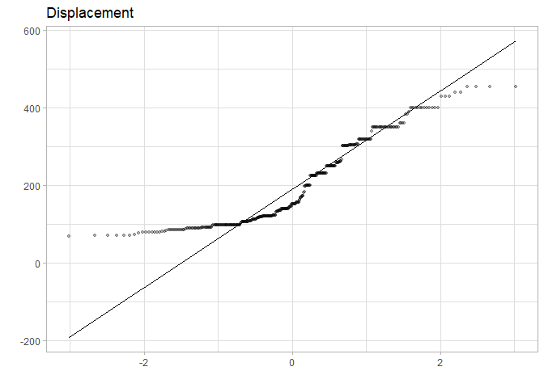

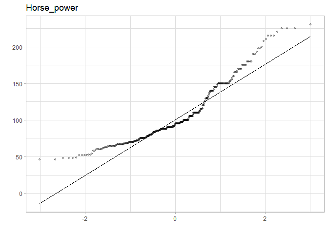

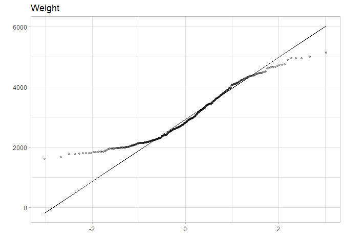

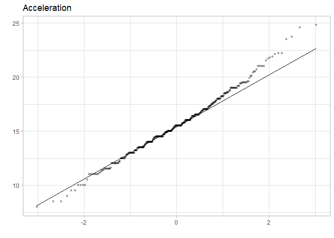

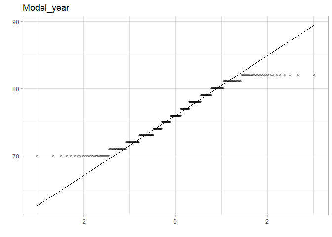

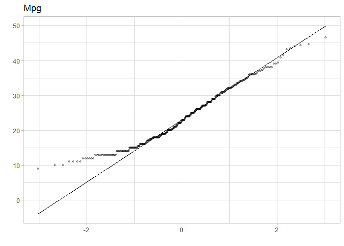

```r
colors <- c("chocolate", "deepskyblue1", "plum1", "hotpink4", "orange", "springgreen4")
bins <- c(10,10,15,15,14,18)
plt <- list(length = length(names))

x<-rnorm(100, mean=0, sd=1)

for (i in 1:length(names)) {
  ggplot(auto, aes_string(sample=names[i])) +
    stat_qq(alpha=.3, fill=colors[i], size=1) +
    stat_qq_line() +
    labs(title="", x="", y="") +
    theme_light() -> plt[[i]]

  print(plt[[i]] + labs(title=sprintf("%s", names[i]), x=""))
}
```

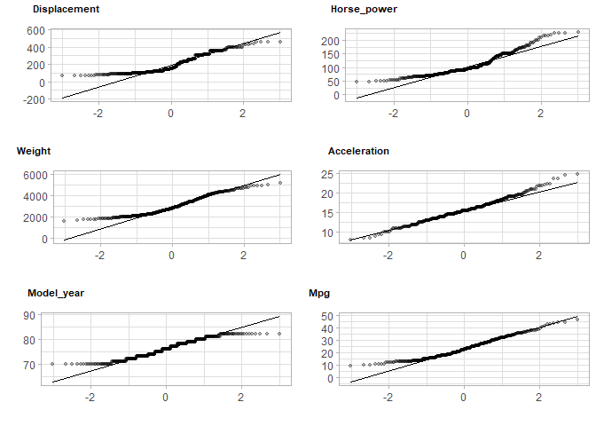

```r
plot_grid(plotlist=plt, ncol=2, labels = names, label_size = 8)
```

Estos gráficos Q-Q nos muestran más claramente que las variables no siguen distribuciones normales. La distribución de Acceleration es la que más se asemeja y eso lo vemos en el estadístico de Shapiro, pero en la cola superior existe una diferencia significativa que hace que el test rechace.

La variable Mpg parece seguir una distribución “exponencial” ??

```r
# ggplot(auto, aes(sample=Mpg)) +
#     stat_qq(alpha=.3, size=1) +
#     stat_qq_line(distribution = stats::qchisq, dparams=(df=1)) +
#     labs(title="", x="", y="") +
#     theme_light()
```

Skewness:

```r
skewCols <- find_skewness(auto)
colnames(auto)[skewCols]
```

```
[1] "Displacement" "Horse_power"  "Weight"
```

```r
cat("Displacement: ")
skewness(auto$Displacement)
cat("Horse_power: ")
skewness(auto$Horse_power)
cat("Weight: ")
skewness(auto$Weight)
cat("Mpg: ")
skewness(auto$Mpg)
```

```
Displacement: [1] 0.6989813
Horse_power: [1] 1.083161
Weight: [1] 0.5175953
Mpg: [1] 0.4553414
```

Sobre la skewness, tal y como se había visto en las gráficas, algunas de las variables la tienen, en los 3 casos positivas (hacia la izquierda).

Los plots nos han dado idea de que Mpg tiene cierta skewness, pero cae por debajo del umbral de 0.5.

### Transformaciones

Las transformaciones necesarias para normalizar una distribución dependen de la variable en cuestion. Primero debemos averiguar que tipo de distribución siguen.

Algunas parecen tener una distribución exponencial

```r
# auto_transform <- preProcess(auto[,skewCols], method=c("YeoJohnson"))
# auto_norm <- predict(auto_transform, auto[,skewCols])

# auto_transform <- preProcess(auto[,1:6], method=c("scale", "center"))
auto_transform <- preProcess(auto[,1:6], method=c("YeoJohnson","scale", "center"))
# transform the dataset using the parameters
auto_norm <- predict(auto_transform, auto[,1:6])

summary(auto_norm)
```

```
  Displacement      Horse_power           Weight          Acceleration
 Min.   :-1.8856   Min.   :-2.59657   Min.   :-2.19582   Min.   :-3.08413
 1st Qu.:-0.8847   1st Qu.:-0.77280   1st Qu.:-0.88990   1st Qu.:-0.61672
 Median :-0.1367   Median :-0.07186   Median :-0.02988   Median : 0.02508
 Mean   : 0.0000   Mean   : 0.00000   Mean   : 0.00000   Mean   : 0.00000
 3rd Qu.: 0.9411   3rd Qu.: 0.77159   3rd Qu.: 0.84752   3rd Qu.: 0.56609
 Max.   : 1.7103   Max.   : 2.16086   Max.   : 1.95352   Max.   : 3.03480
   Model_year           Mpg
 Min.   :-1.6431   Min.   :-2.45780
 1st Qu.:-0.8047   1st Qu.:-0.79553
 Median : 0.0172   Median : 0.04412
 Mean   : 0.0000   Mean   : 0.00000
 3rd Qu.: 0.8236   3rd Qu.: 0.78143
 Max.   : 1.6154   Max.   : 2.32155
```

Aunque para regresión no es absolutamente necesario, podemos estandarizar los datos a media 0 y dev 1, facilitando un poco los cálculos. La inferencia estadística de la regresión no va a variar, por lo que es conveniente hacerlo. Haciendo esto debemos tener cuidado a la hora de interpretar los resultados de la regresión para no confundirnos.

```r
# auto %>% apply(2, function(c) {
#   fit <- fitdistr(c, "exponential")
#
#   # goodness of fit test
#   ks.test(c, "pexp", fit$estimate) # p-value > 0.05 -> distribution not refused
# })
#
# auto %>% apply(2, function(c) {
#   fit <- fitdistr(c, "chi-squared", start=list(df=3),method="Brent",lower=0.1,upper=100)
#
#   # goodness of fit test
#   # ks.test(c, "pexp", fit$estimate) # p-value > 0.05 -> distribution not refused
#   ks.test(c,pchisq,df=10)
# })


# hist(auto$Displacement, freq = FALSE, breaks = 100, xlim = c(0, quantile(auto$Displacement, 0.99)))
# curve(dexp(x, rate = fit1$estimate), from = 0, col = "red", add = TRUE)
```

```r
# normality(auto_norm) %>% filter(p_value < 0.05)
```

```r
# colors <- c("chocolate", "deepskyblue1", "plum1", "hotpink4", "orange", "springgreen4")
# bins <- c(10,10,15,15,14,18)
# plt <- list(length = length(names))
#
# x<-rnorm(100, mean=0, sd=1)
#
# for (i in 1:length(names)) {
#   ggplot(auto_norm, aes_string(sample=names[i])) +
#     stat_qq(alpha=.3, fill=colors[i], size=1) +
#     stat_qq_line() +
#     labs(title="", x="", y="") +
#     theme_light() -> plt[[i]]
#
#   print(plt[[i]] + labs(title=sprintf("%s", names[i]), x=""))
# }
#
# plot_grid(plotlist=plt, ncol=2, labels = names, label_size = 8)
```

```r
# shapiro.test(auto_norm$Acceleration)
#
# ggplot(auto_norm, aes(sample=Acceleration)) +
#     stat_qq(alpha=.3, size=1) +
#     stat_qq_line() +
#     labs(title="", x="", y="") +
#     theme_light()

# colors <- c("chocolate", "deepskyblue1", "plum1", "hotpink4", "orange", "springgreen4")
# bins <- c(10,10,15,15,14,18)
# plt <- list(length = length(names))
#
# for (i in 1:length(names)) {
#   ggplot(auto, aes_string(x=names[i])) +
#     geom_histogram(aes(y=..density..), bins=bins[i], color="white", fill=colors[i]) +
#     geom_density(alpha=.3, fill="black", size=1) +
#     # labs(title=sprintf("%s", names[i]), x="") +
#     labs(title="", x="", y="") +
#     theme_light() -> plt[[i]]
#
#   print(plt[i])
# }
#
# plot_grid(plotlist=plt, ncol=2, labels = names, label_size = 8)
#
#
# # QQ-plots
#
# x<-rnorm(100, mean=0, sd=1)
#
# for (i in 1:length(names)) {
#   ggplot(auto_norm, aes_string(sample=names[i])) +
#     stat_qq(alpha=.3, fill=colors[i], size=1) +
#     stat_qq_line() +
#     labs(title="", x="", y="") +
#     theme_light() -> plt[[i]]
#
#   print(plt[i])
# }
#
# plot_grid(plotlist=plt, ncol=2, labels = names, label_size = 8)
```

### Análisis de correlación

Tenemos que tener en cuenta que las variables no siguen distribuciones normales. Aunque el coeficiente de Pearson no asume normalidad (si asume varianza y covarianza finitas), podemos usar el coeficiente de Kendall para los cálculos. Independientemente del método usado vamos a obtener las mismas correlaciones en este dataset, solo varía la fuerza con la que se dan.

Corrplot

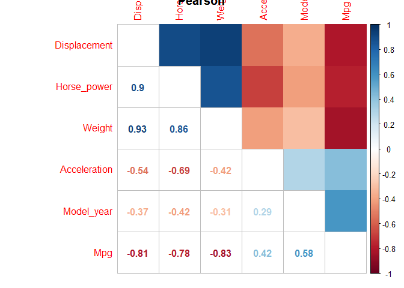

```r
corrplot.mixed(cor(auto), tl.pos="lt", upper="color", title="Pearson")
```

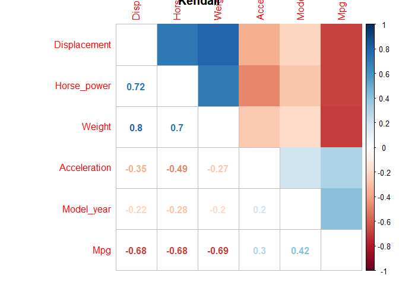

```r
corrplot.mixed(cor(auto, method="kendall"), tl.pos="lt", upper="color", title="Kendall")
```

Estas gráficas nos dicen que existe una alta correlación en el dataset, generalmente entre todas las variables (a excepción de Model_year), pero extremadamente fuerte en las parejas:

1. Horse_power & Displacement
2. Weight & Displacement
3. Weight & Horse_power
4. Acceleration & Horse_power
5. Mpg & Horse_power
6. Mpg & Displacement
7. Mpg & Weight

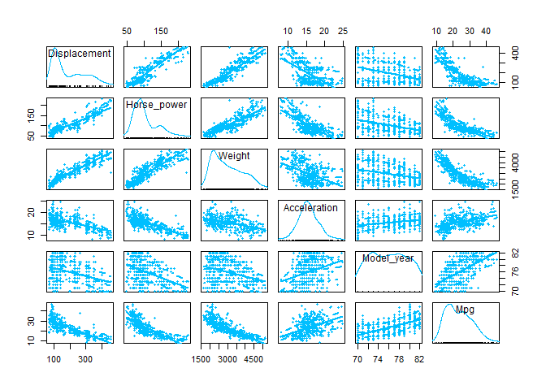

```r
scatterplotMatrix(auto, pch=20, col="deepskyblue")
```

El scatterplot anterior nos muestra mejor la forma de estas correlaciones. Vemos que en todos los casos en los que se da una correlación positiva existe una tendencia lineal entre los datos de ambas variables, y en las negativas una tendencia logarítmica.

Vamos a mostrar algunas Positivas

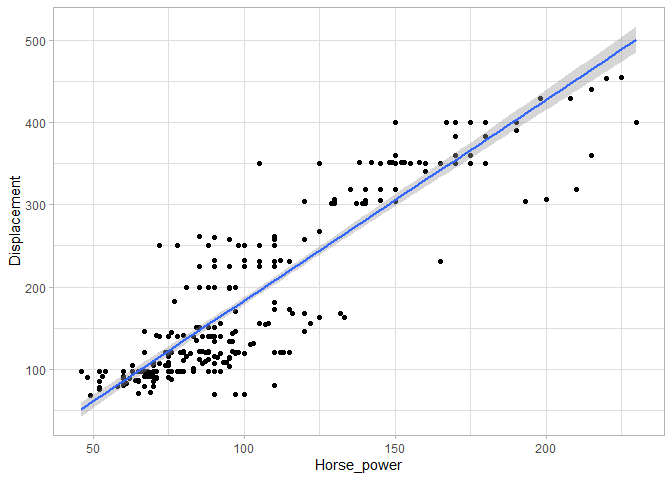

```r
ggplot(auto, aes(x=Horse_power, y=Displacement)) +
  geom_point() +
  geom_smooth(formula = y~x, method=glm) +
  theme_light()
```

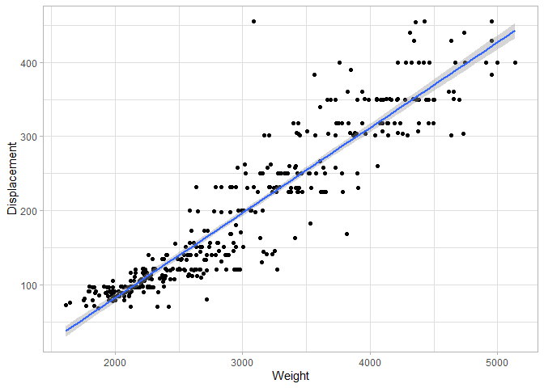

```r
ggplot(auto, aes(x=Weight, y=Displacement)) +
  geom_point() +
  geom_smooth(formula = y~x, method=glm) +
  theme_light()
```

Negativas

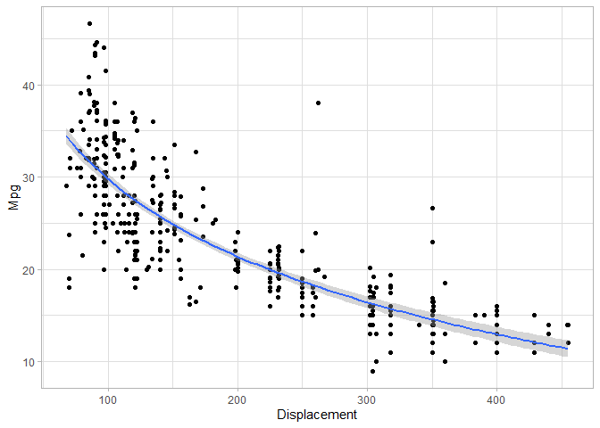

```r
ggplot(auto, aes(x=Displacement, y=Mpg)) +
  geom_point() +
  geom_smooth(formula = y~log(x), method=glm) +
  theme_light()
```

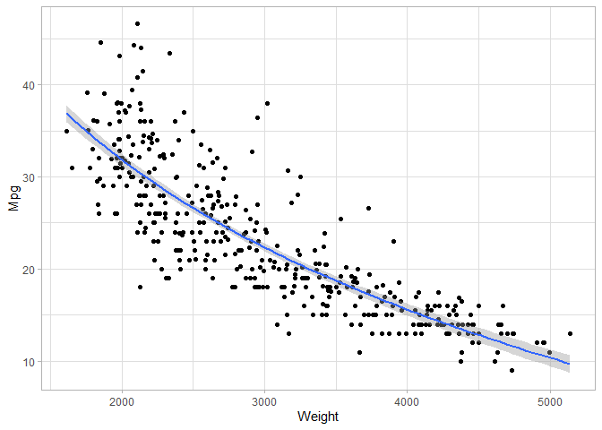

```r
ggplot(auto, aes(x=Weight, y=Mpg)) +
  geom_point() +
  geom_smooth(formula = y~log(x), method=glm) +
  theme_light()
```

Previsualicación de las variables respecto a la salida

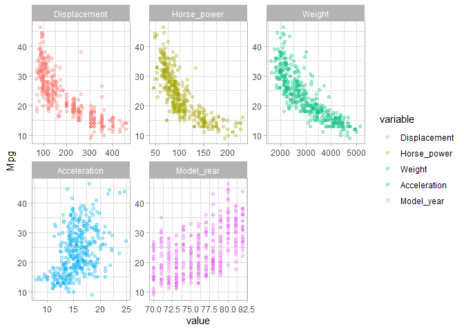

```r
ggplot(melt(auto, "Mpg"), aes(x=value, y=Mpg, color=variable)) +
  geom_point(alpha=0.3) +
  facet_wrap(.~variable, scale="free") +
  theme_light()
```

Se aprecia alta correlación entre Displacement, Horse_power, Weight respecto de la salida.

Como habíamos supuesto en la hipótesis H.9, Horse_power podría depender de Displacement y Weight. Esta claro que la potencia de un motor va a depender de la cilindrada y el peso que tenga.

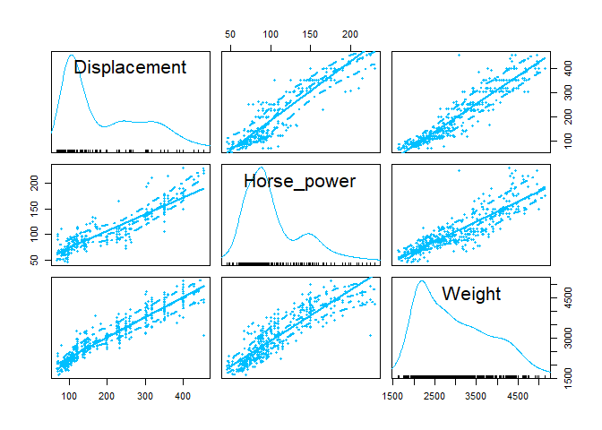

```r
auto %>%
  dplyr::select(Displacement, Horse_power, Weight) %>%
  scatterplotMatrix(pch=20, col="deepskyblue")
```

Podemos apreciar como la función de densidad de Horse_power parece una (“MEDIANIZACIÓN”) de las otras dos.

Vamos a intentar comprobarlo

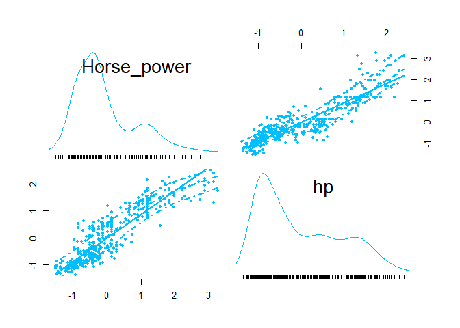

```r
scale(auto) %>%
  as.data.frame() %>%
  mutate(hp = (Displacement+Weight) / 2) %>%
  dplyr::select(Horse_power, hp) %>%
  scatterplotMatrix(pch=20, col="deepskyblue")
```

Viendo que no son tan similares como creíamos, buscamos diferentes fórmulas para el cálculo de los caballos de vapor, y vemos que las fórmulas son un poco más complejas y no tenemos exactamente los datos necesarios para utilizarlas (no se descarta que no se puedan deducir, pero no sería un cálculo evidente)

### Tratamiento de variables

Para este dataset, al ser casi todas las variables numéricas continuas, existen pocos tratamientos que aplicar.

No tenemos variables categóricas que transformar.

Para añadir interpretabilidad, podríamos agrupar la variable Weight en intervalos, pero puesto que vamos a aplicar regresión sería más conveniente realizarlo con los resultados finales.

### Ordenaciones

Volvemos a mostrar la cabecera de los datos:

```r
head(auto)
```

| Displacement | Horse_power | Weight | Acceleration | Model_year | Mpg |
| --- | --- | --- | --- | --- | --- |
| 91 | 70 | 1955 | 20.5 | 71 | 26.0 |
| 232 | 100 | 2789 | 15.0 | 73 | 18.0 |
| 350 | 145 | 4055 | 12.0 | 76 | 13.0 |
| 318 | 140 | 4080 | 13.7 | 78 | 17.5 |
| 113 | 95 | 2372 | 15.0 | 70 | 24.0 |
| 97 | 60 | 1834 | 19.0 | 71 | 27.0 |

En este caso no es necesario aplicar ninguna reorganización. Cada variable ocupa su propia columna, y contiene un único tipo de información, con unidades de observación diferentes No existe ninguna relación entre variables sobre la información que codifican (en el sentido de que podrían agruparse).

#### Resolución de hipótesis

Nos habíamos planteado las siguientes hipótesis

- H.1: Horse_power puede influir en Mpg: A más potencia, más consumo.

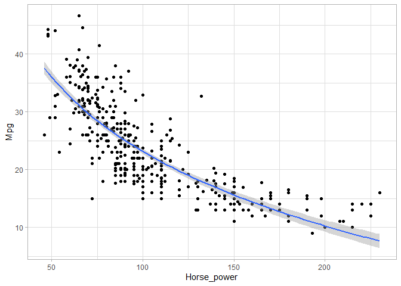

```r
ggplot(auto, aes(x=Horse_power, y=Mpg)) +
  geom_point() +
  geom_smooth(formula = y~log(x), method=glm) +
  theme_light()
```

Con el plot y los resultados de la matriz de correlación queda claro que existe una correlación negativa entre estas dos variables. Por tanto, podemos considerar Horse_power como un buen candidato para la regresión

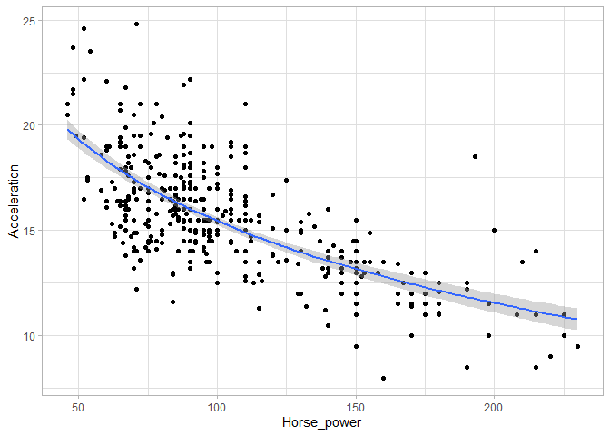

```r
ggplot(auto, aes(x=Horse_power, y=Acceleration)) +
  geom_point() +
  geom_smooth(formula = y~log(x), method=glm) +
  theme_light()
```

- H.5: Viendo que contamos con un rango pequeño de años, no debería haber un cambio significativo de prestaciones entre años.

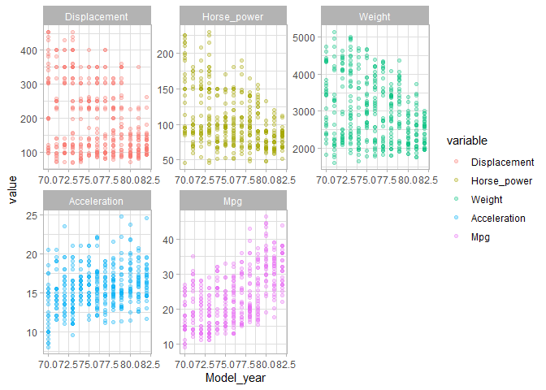

```r
ggplot(melt(auto, "Model_year"), aes(y=value, x=Model_year, color=variable)) +
  geom_point(alpha=0.3) +
  facet_wrap(.~variable, scale="free") +
  theme_light()
```

Existe una alta dispersión de los datos en cada una de las variables, pero aún así se aprecia tendencias en las variables. Acceleartion y Mpg tienden a aumentar, y Displacement, Horse_power y Weight tienden a disminuir. También vemos que la dispersión en las prestaciones de los coches disminuyen ligeramente.

Podemos creer en principio que puede deberse a un decremento del número de instancias con el paso de los años, pero recordamos que en general los datos están repartidos equitativamente

```r
table(auto$Model_year)
```

```
70 71 72 73 74 75 76 77 78 79 80 81 82
29 27 28 40 26 30 34 28 36 29 27 28 30
```

Podemos ver cómo varían los rangos para cada año

```r
years <- auto %>% group_split(Model_year)

for (y in years) {
  cat("Year: ")
  y$Model_year[1] %>% cat()
  y %>% apply(2, range) %>% as.data.frame() %>% print()
}
```

```
Year: 70  Displacement Horse_power Weight Acceleration Model_year Mpg
1           97          46   1835          8.0         70   9
2          455         225   4732         20.5         70  27
Year: 71  Displacement Horse_power Weight Acceleration Model_year Mpg
1           71          60   1613         11.5         71  12
2          400         180   5140         20.5         71  35
Year: 72  Displacement Horse_power Weight Acceleration Model_year Mpg
1           70          54   2100         11.0         72  11
2          429         208   4633         23.5         72  28
Year: 73  Displacement Horse_power Weight Acceleration Model_year Mpg
1           68          46   1867          9.5         73  11
2          455         230   4997         21.0         73  29
Year: 74  Displacement Horse_power Weight Acceleration Model_year Mpg
1           71          52   1649         13.5         74  13
2          350         150   4699         21.0         74  32
Year: 75  Displacement Horse_power Weight Acceleration Model_year Mpg
1           90          53   1795         11.5         75  13
2          400         170   4668         21.0         75  33
Year: 76  Displacement Horse_power Weight Acceleration Model_year Mpg
1           85          52   1795         12.0         76  13
2          351         180   4380         22.2         76  33
Year: 77  Displacement Horse_power Weight Acceleration Model_year Mpg
1           79          58   1825         11.1         77  15
2          400         190   4335         19.0         77  36
Year: 78  Displacement Horse_power Weight Acceleration Model_year  Mpg
1           78          48   1800         11.2         78 16.2
2          318         165   4080         21.5         78 43.1
Year: 79  Displacement Horse_power Weight Acceleration Model_year  Mpg
1           85          65   1915         11.3         79 15.5
2          360         155   4360         24.8         79 37.3
Year: 80  Displacement Horse_power Weight Acceleration Model_year  Mpg
1           70          48   1845         11.4         80 19.1
2          225         132   3381         23.7         80 46.6
Year: 81  Displacement Horse_power Weight Acceleration Model_year  Mpg
1           79          58   1755         12.6         81 17.6
2          350         120   3725         20.7         81 39.1
Year: 82  Displacement Horse_power Weight Acceleration Model_year Mpg
1           91          52   1965         11.6         82  22
2          262         112   3015         24.6         82  44
```

- H.6: Pero debería existir una tendencia de mejora de prestaciones con los años, incluyendo aumento de Displacement, Horse_power y Acceleration.

- H.7: Model_year podría no mostrar relación con Mpg: Pese al paso de los años si contamos con diferentes tipos de vehículos (todoterrenos, familiares, deportivos…) podría haber un consumo dispar. (Si existiera tendencia, viendo que los años son de las últimas décadas del siglo XX, podría ir el consumo hacia abajo)

Hemos visto que existe tendencia, lineal con gran dispersión, y positiva.

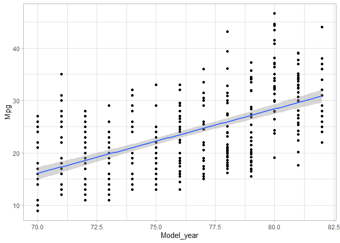

```r
ggplot(auto, aes(x=Model_year, y=Mpg)) +
  geom_point() +
  geom_smooth(formula = y~x, method=glm) +
  theme_light()
```

Por desgracia no contamos información sobre los modelos de los coches

Podemos ver como se ubican los diferentes años en un plot Horse_power vs Mpg

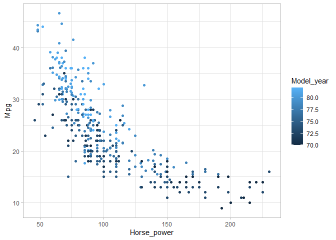

```r
ggplot(auto, aes(x=Horse_power, y=Mpg, color=Model_year)) +
  geom_point() +
  theme_light()
```

Y vemos que no se puede afirmar la hipótesis, los coches están entremezclados por diferentes años

- H.8: Esta última hipótesis se puede aplicar al resto de variables, indicándonos que Model_year no debería tener relevancia para este problema de regresión.

No podemos afirmar la hipótesis anterior y por consiguiente esta tampoco.

- H.9: Horse_power podría depender de las variables Displacement y Weight

Lo hemos comentado anteriormente

#### Conclusiones

Como conclusiones podemos decir que tenemos un dataset altamente correlacionado, distribuído de forma no normal pero con la información bien representada. Existen relaciones fuertes entre las variables de entrada y de las de salida para la regresión que probablemente nos ayuden a solucionar con facilidad el problema.

A falta de descubrir las distribuciones que siguen las variables para ver si merece la pena transformarlas a una distribución normal, podemos sin ninguna duda aplicar una estandarización de los datos (puesto que sabemos que no afecta negativamente al problema de regresión), siempre y cuando lo tengamos en cuenta a la hora de analizar los resultados.

Se nos pide elegir 5 regresores para la regresión y contamos exactamente con ese número, por lo que no podemos descartar ninguna variable. Aún así, hemos visto que tenemos algunas variables más interesentas que otras. Varibles correladas con la salida nos aumentan las posibilidades de obtener un buen regresor, pero debemos evitar usar variables correladas entre sí para evitar la multicolinealidad. (https://statisticsbyjim.com/regression/multicollinearity-in-regression-analysis/#:~:text=Multicollinearity%20occurs%20when%20independent%20variables,model%20and%20interpret%20the%20results.) (referenciar esta frase en el apartado de regresión)